# Hypergeometric Distribution

Kris Gunsalus

10/7/2020

## Hypergeometric Distribution

The hypergeometric is similar to the **binomial distribution**, except it defines the *probability of obtaining $x$ independent successes* when sampling *without replacement*.

Examples:

- The number of fish caught as hunting season progresses.
- The number of aces in a hand of 5 cards.
- The number of green Eppendorf tubes in a handful of tubes grabbed from a bag of mixed color tubes.
- The number of genes with a specific functional annotation (e.g. GO term) in the genome (often used for enrichment analysis in gene expression studies)

Since we are sampling **without replacement**, each trial affects the probability of the next outcome – in other words, we need an equation to find the relative frequency of $x$ in a shrinking sample space. The PDF is defined as:

$$f(x) = P(X = x) = \frac{{M \choose x}{N - M \choose n - x}}{N \choose n}$$

where:

- $x \in \{0,1,2,...,n\}$ is the number of successful trials
- $N \in \{1,2,...\}$ is the total number of selectable items
- $M \in \{0,1,2,...,N\}$ is the total number of possible successful outcomes (i.e. the number of items in the group of interest)
- $n \in \{0,1,2,...,N\}$ is the number of items sampled

The above equation contains **three parts**:

- ${M}\choose{x}$ = The number of ways to choose $x$ successes from $M$, the number of possible successes
- ${N-M}\choose{n-x}$ = The number of ways to get $n-x$ failures from $N-M$, the number of possible failures
- ${N}\choose{n}$ = The number of ways to draw $n$ items from $N$, the total number of items

Formally, if the random variable $X$ follows a hypergeometric distribution with parameters $(n,M,N)$, we write $X \sim HYP(n,M,N)$.

### Relationship to the binomial distribution

- **Binomial**: This is useful for modeling sampling with replacement, or sampling without replacement from a very large population, since in both cases the probability of success is essentially the same for every trial.
- **Hypergeometric**: This is suited to a situation when the population of items to choose from is finite and there is no replacement, because each trial will change the probability of subsequent trials.

When the proportion of items drawn from the total is very small, sampling from these two distributions is very similar, since the probabilities will not change that much overall.

In the limit of an infinite number of items to choose from (i.e. as $N$ goes to $\infty$), the hypergeometric distribution converges on the binomial distribution with parameters $(n,p)$, where $p=\frac{M}{N}$ is the proportion of successes.

$$X \sim HYP(n,M,N) \underset{p=\frac{M}{N}}{\overset{N\rightarrow\infty}{\longrightarrow}} X \sim BIN(n,p)$$

### Example: hypergeometric vs. binomial probabilities

Let’s model this using they hypergeometric distribution and compare the results with a binomial model. The procedure is:

- Take a sample of size $k$ from either a hypergeometric or a binomial distribution with equivalent parameters.
- Repeat this 1000 times.
- Draw a histogram of the number of transformants, using `prob=T` to plot densities rather than raw numbers.
- Add density lines showing the smoothened distribution of observations.

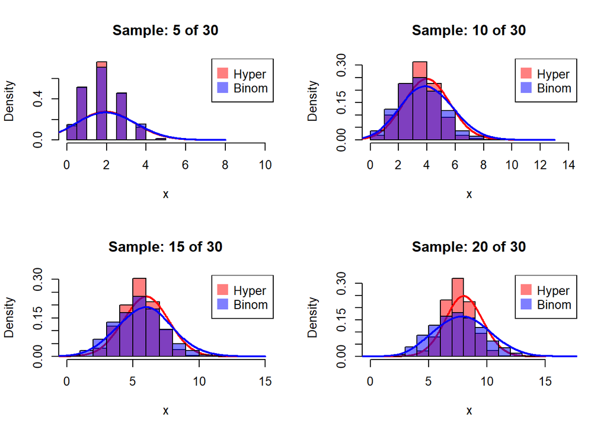

```r
k = c(5,10,15,20)  # k = number of items sampled
N = 30             # N = total
M = N*0.4             # M = total possible successes
N_M = N-M          # N - M = total possible failures
obs = 1000         # number of observations

par(mfrow=c(2,2))

for (i in k) {
  Hyper=rhyper(obs, M, N_M, i)  # rhyper(nn=obs, m=M, n=N-M, k=k)
  Binom=rbinom(obs, size=i, prob=M/N)  # rbinom(n=obs, size=k, prob=M/N)

  title = paste("Sample: ",i," of ",N, sep="")
  x_max = max(Hyper) + 5
  # First distribution
  hist(Hyper, xlim=c(0,x_max), col=rgb(1,0,0,0.5), xlab="x", prob=T, main=title )
  lines(density(Hyper,bw=1), col="red", lwd=2)

  # Second with add=T to plot on top
  hist(Binom,  xlim=c(0,x_max), col=rgb(0,0,1,0.5),  prob=T, add=T)
  lines(density(Binom,bw=1), col="blue", lwd=2)

  # Add legend
  legend("topright", legend=c("Hyper","Binom"), col=c(rgb(1,0,0,0.5),
                                                      rgb(0,0,1,0.5)), pt.cex=2, pch=15 )
}
```

If the total number of items is a lot bigger, there is much less of a difference between the two distributions:

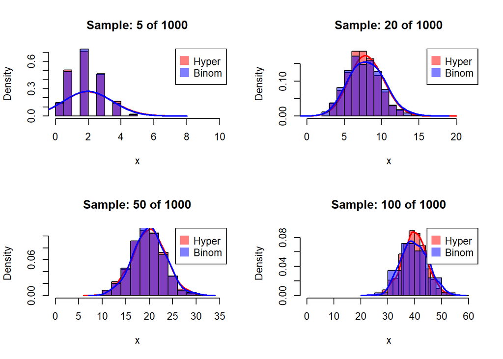

```r
k = c(5,20,50,100)  # k = number of items sampled
N = 1000             # N = total
M = N*0.4             # M = total possible successes
N_M = N-M          # N - M = total possible failures
obs = 1000         # number of observations

par(mfrow=c(2,2))

for (i in k) {
  Hyper=rhyper(obs, M, N_M, i)  # rhyper(nn=obs, m=M, n=N-M, k=k)
  Binom=rbinom(obs, size=i, prob=M/N)  # rbinom(n=obs, size=k, prob=M/N)

  title = paste("Sample: ",i," of ",N, sep="")
  x_max = max(Hyper) + 5
  # First distribution
  hist(Hyper, xlim=c(0,x_max), col=rgb(1,0,0,0.5), xlab="x", prob=T, main=title )
  lines(density(Hyper,bw=1), col="red", lwd=2)

  # Second with add=T to plot on top
  hist(Binom, xlim=c(0,x_max), col=rgb(0,0,1,0.5),  prob=T, add=T)
  lines(density(Binom,bw=1), col="blue", lwd=2)

  # Add legend
  legend("topright", legend=c("Hyper","Binom"), col=c(rgb(1,0,0,0.5),
                                                      rgb(0,0,1,0.5)), pt.cex=2, pch=15 )
}
```